# Customer Retention: Survival Analysis of Churn

Author

Hisyam Maheswara Kusuma Saputro

Published

October 26, 2026

## Introduction

Predicting whether a customer will churn is a common classification task, but it throws away a crucial question: *when*. Two customers flagged as “will churn” are not equivalent if one is likely to leave next month and the other in two years, yet a standard classifier treats them the same. Survival analysis keeps the time dimension intact, modeling not just whether a customer will churn, but how long they are expected to stay and which factors accelerate or delay churn.

This project analyzes churn in a [telecom customer dataset](https://www.kaggle.com/datasets/blastchar/telco-customer-churn) using three methods: Kaplan-Meier curves for a model-free view of survival, Cox Proportional Hazards for an interpretable semi-parametric model, and Random Survival Forest to test whether relaxing Cox’s linearity assumption improves predictive performance. The question is not just “what predicts churn”, but “does a more flexible, less interpretable model actually earn its complexity here”.

## Data

The data is the [IBM Telco Customer Churn](https://www.kaggle.com/datasets/blastchar/telco-customer-churn) sample from Kaggle: 7,043 customers of a fictional telecom company, with account details, subscribed services, demographics, tenure in months (`tenure`) and a churn flag (`Churn`). Eleven customers with `tenure = 0` (new sign-ups, all still active) were excluded because they contribute no time at risk, leaving 7,032 customers. The table below gives an overview of the variables after this cleaning.

| Variable | Type | Unique | Examples |
| --- | --- | --- | --- |
| customerID | character | 7032 | 7590-VHVEG, 5575-GNVDE, 3668-QPYBK |
| gender | character | 2 | Female, Male |
| SeniorCitizen | factor | 2 | No, Yes |
| Partner | character | 2 | Yes, No |
| Dependents | character | 2 | No, Yes |
| tenure | numeric | 72 | 1, 34, 2 |
| PhoneService | character | 2 | No, Yes |
| MultipleLines | character | 3 | No phone service, No, Yes |
| InternetService | character | 3 | DSL, Fiber optic, No |
| OnlineSecurity | character | 3 | No, Yes, No internet service |
| OnlineBackup | character | 3 | Yes, No, No internet service |
| DeviceProtection | character | 3 | No, Yes, No internet service |
| TechSupport | character | 3 | No, Yes, No internet service |
| StreamingTV | character | 3 | No, Yes, No internet service |
| StreamingMovies | character | 3 | No, Yes, No internet service |
| Contract | character | 3 | Month-to-month, One year, Two year |
| PaperlessBilling | character | 2 | Yes, No |
| PaymentMethod | character | 4 | Electronic check, Mailed check, Bank transfer (automatic) |
| MonthlyCharges | numeric | 1584 | 29.85, 56.95, 53.85 |
| TotalCharges | numeric | 6530 | 29.85, 1889.5, 108.15 |
| Churn | numeric | 2 | 0, 1 |

### Censoring check

```
Event (churn) rate: 26.58%
```

About 27% of customers are recorded as churned (events). The remaining 73% are right-censored: they were still active at data collection, so their true tenure is at least the recorded value but unknown. They are kept in the analysis and contribute their tenure as time at risk. Note that this dataset (an IBM sample for a fictional telco) records churn as leaving within the last month, so it is a snapshot rather than a full cohort follow-up. Absolute survival probabilities should be read as illustrative; the focus here is on relative differences between customer groups.

### Predictor Screening

Two predictors were excluded before modeling. `TotalCharges` is approximately `tenure` × `MonthlyCharges`, so it encodes the follow-up time itself, the quantity being modeled, and would leak it into the predictors. `MonthlyCharges` is almost fully determined by the customer’s service bundle ($R^2 = 0.999$ when regressed on the service columns), which made the individual service effects unstable. Screening was done after an initial model fit showed unstable estimates for the service variables; the variance inflation factors below identify the cause.

| Variable | VIF (with MonthlyCharges) | VIF (without MonthlyCharges) |
| --- | --- | --- |
| gender | 1.0 | 1.0 |
| SeniorCitizen | 1.2 | 1.2 |
| Partner | 1.4 | 1.4 |
| Dependents | 1.4 | 1.4 |
| PhoneService | 34.9 | 1.3 |
| MultipleLines | 7.2 | 1.4 |
| InternetService | 24.7 | 1.9 |
| OnlineSecurity | 6.3 | 1.4 |
| OnlineBackup | 6.7 | 1.3 |
| DeviceProtection | 6.9 | 1.5 |
| TechSupport | 6.5 | 1.5 |
| StreamingTV | 24.1 | 1.6 |
| StreamingMovies | 24.1 | 1.6 |
| Contract | 1.3 | 1.3 |
| PaperlessBilling | 1.2 | 1.2 |
| PaymentMethod | 1.1 | 1.1 |
| MonthlyCharges | 863.7 | NA |

With `MonthlyCharges` included, its VIF is about 864 and the service variables (`InternetService`, `PhoneService`, `StreamingTV`, `StreamingMovies`) range from 24 to 35. After exclusion, all VIFs are below 2. Price sensitivity is therefore not assessed separately. A VIF above 10 was treated as problematic.

## Exploratory Analysis

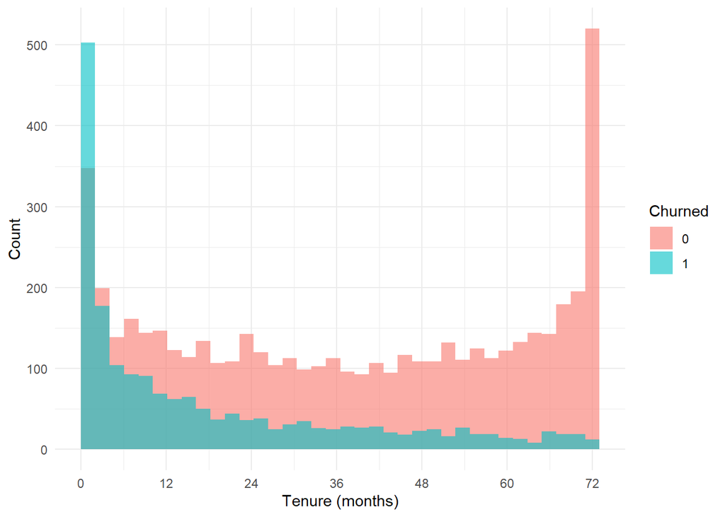

Churned customers are concentrated at short tenures: their median tenure is 10 months, versus 38 months for customers still active, and 56% of churn events occur within the first 12 months. The share of customers who churn falls steadily with tenure, from about 48% among those with 1-12 months to about 7% among those with 61-72 months. Active customers are spread across the whole range, with a visible spike at 72 months. This reflects the end of the observation window, not a real cluster of loyal customers.

These tenures are not true lifetimes. Active customers are right-censored, so their recorded tenure understates how long they will stay, and comparing the two medians directly would be misleading. The Kaplan-Meier estimator in the next section handles this properly.

## Kaplan-Meier Estimation

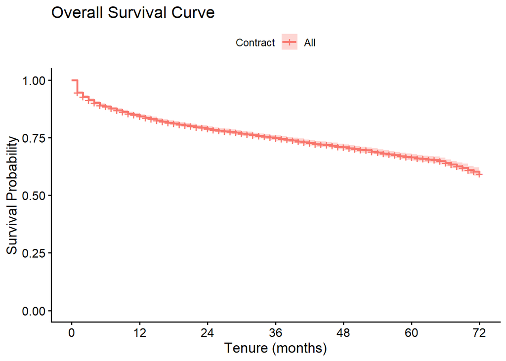

The overall curve falls to about 84% at 12 months, 75% at 36 months and 66% at 60 months. It never drops below 50%, so the median survival time is not reached for the full sample.

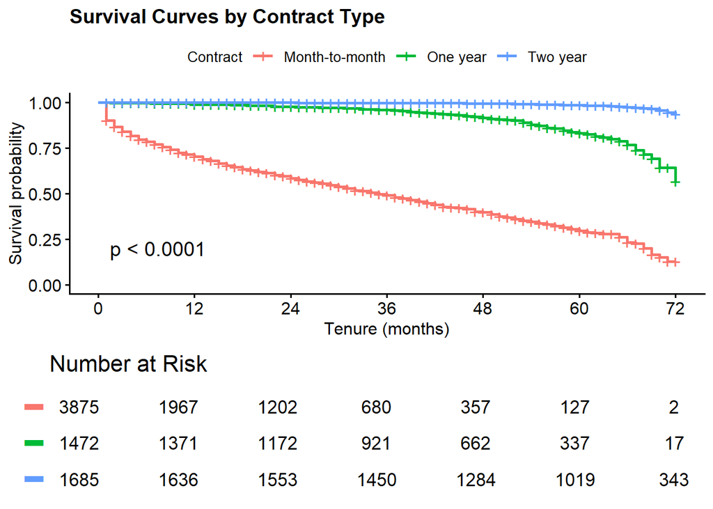

The curves separate sharply by contract type (log-rank p < 0.0001). Among month-to-month customers, survival drops to about 70% at 12 months and 49% at 36 months, with a median of 35 months. One-year contract customers retain about 99% at 12 months and 83% at 60 months, and two-year contract customers retain about 99% even at 60 months. Curves beyond about month 60 rest on few customers (month-to-month: 127 at risk at month 60 and 2 at month 72; one-year: 17 at month 72), so their right tails should be read with caution. This is the clearest signal in the dataset and foreshadows the Cox model’s largest hazard ratios below.

## Cox Proportional Hazards Model

```r
cox_fit <- coxph(Surv(tenure, Churn) ~ ., data = df_model)
broom::tidy(cox_fit, exponentiate = TRUE, conf.int = TRUE) %>%
  transmute(
    Term      = term,
    HR        = round(estimate, 2),
    `95% CI`  = sprintf("%.2f – %.2f", conf.low, conf.high),
    `p-value` = ifelse(p.value < 0.001, "<0.001", sprintf("%.3f", p.value))
  ) %>%
  knitr::kable(align = "lrrr")
```

| Term | HR | 95% CI | p-value |
| --- | --- | --- | --- |
| genderMale | 0.92 | 0.84 – 1.01 | 0.065 |
| SeniorCitizenYes | 0.93 | 0.83 – 1.04 | 0.205 |
| PartnerYes | 0.60 | 0.54 – 0.66 | <0.001 |
| DependentsYes | 0.95 | 0.83 – 1.08 | 0.429 |
| PhoneServiceYes | 1.10 | 0.90 – 1.34 | 0.354 |
| MultipleLinesYes | 0.63 | 0.57 – 0.70 | <0.001 |
| InternetServiceFiber optic | 1.47 | 1.28 – 1.70 | <0.001 |
| InternetServiceNo | 0.33 | 0.26 – 0.42 | <0.001 |
| OnlineSecurityYes | 0.52 | 0.46 – 0.59 | <0.001 |
| OnlineBackupYes | 0.52 | 0.47 – 0.58 | <0.001 |
| DeviceProtectionYes | 0.72 | 0.65 – 0.81 | <0.001 |
| TechSupportYes | 0.66 | 0.58 – 0.75 | <0.001 |
| StreamingTVYes | 0.96 | 0.86 – 1.07 | 0.468 |
| StreamingMoviesYes | 0.87 | 0.79 – 0.97 | 0.014 |
| ContractOne year | 0.20 | 0.17 – 0.24 | <0.001 |
| ContractTwo year | 0.04 | 0.03 – 0.05 | <0.001 |
| PaperlessBillingYes | 1.20 | 1.07 – 1.34 | 0.001 |
| PaymentMethodCredit card (automatic) | 0.92 | 0.77 – 1.10 | 0.354 |
| PaymentMethodElectronic check | 1.80 | 1.56 – 2.07 | <0.001 |
| PaymentMethodMailed check | 1.76 | 1.48 – 2.09 | <0.001 |

```r
cc <- summary(cox_fit)$concordance
cat(sprintf("Concordance = %.3f (se = %.3f); n = %d, events = %d",
            cc["C"], cc["se(C)"], cox_fit$n, cox_fit$nevent))
```

```
Concordance = 0.866 (se = 0.003); n = 7032, events = 1869
```

Hazard ratios (HR) are relative to the reference level; 95% confidence intervals in brackets.

- **Contract length dominates.** Relative to month-to-month, one-year contracts cut churn hazard by about 80% (HR 0.20 [0.17, 0.24]) and two-year contracts by about 96% (HR 0.04 [0.03, 0.05]). These are time-averaged effects; see the proportional hazards check below.
- **Internet service type matters.** Fiber optic customers have about 47% higher hazard than DSL customers (HR 1.47 [1.28, 1.70]); customers with no internet service have about 67% lower hazard (HR 0.33 [0.26, 0.42]).
- **Payment method.** Electronic check (HR 1.80 [1.56, 2.07]) and mailed check (HR 1.76 [1.48, 2.09]) customers have roughly 1.8x the hazard of those on automatic bank transfer. Credit card (automatic) does not differ significantly.
- **Add-on services are associated with lower hazard.** Online security (HR 0.52), online backup (HR 0.52), tech support (HR 0.66), device protection (HR 0.72) and multiple lines (HR 0.63).
- **Partner and billing.** Having a partner is associated with lower hazard (HR 0.60 [0.54, 0.66]); paperless billing with higher hazard (HR 1.20 [1.07, 1.34]).
- Gender, senior citizen status, dependents, phone service and streaming TV are not significant at the 5% level; streaming movies is weakly significant (HR 0.87, p = 0.014).

Model concordance is 0.866 (se 0.003), computed on the full sample: strong discriminative ability for a churn model, without relying on any variable that encodes the follow-up time.

### Proportional Hazards Assumption Check

```r
ph_tbl <- function(z) {
  as.data.frame(z$table) %>%
    tibble::rownames_to_column("Term") %>%
    transmute(
      Term,
      `Chi-sq`  = round(chisq, 1),
      df        = df,
      `p-value` = ifelse(p < 0.001, "<0.001", sprintf("%.3f", p))
    ) %>%
    knitr::kable(align = "lrrr")
}
ph_test <- cox.zph(cox_fit)
ph_tbl(ph_test)
```

| Term | Chi-sq | df | p-value |
| --- | --- | --- | --- |
| gender | 0.0 | 1 | 0.940 |
| SeniorCitizen | 0.9 | 1 | 0.330 |
| Partner | 16.8 | 1 | <0.001 |
| Dependents | 1.1 | 1 | 0.295 |
| PhoneService | 7.2 | 1 | 0.007 |
| MultipleLines | 61.8 | 1 | <0.001 |
| InternetService | 54.4 | 2 | <0.001 |
| OnlineSecurity | 22.6 | 1 | <0.001 |
| OnlineBackup | 30.3 | 1 | <0.001 |
| DeviceProtection | 39.6 | 1 | <0.001 |
| TechSupport | 40.7 | 1 | <0.001 |
| StreamingTV | 84.2 | 1 | <0.001 |
| StreamingMovies | 71.3 | 1 | <0.001 |
| Contract | 81.4 | 2 | <0.001 |
| PaperlessBilling | 4.6 | 1 | 0.032 |
| PaymentMethod | 51.8 | 3 | <0.001 |
| GLOBAL | 305.8 | 20 | <0.001 |

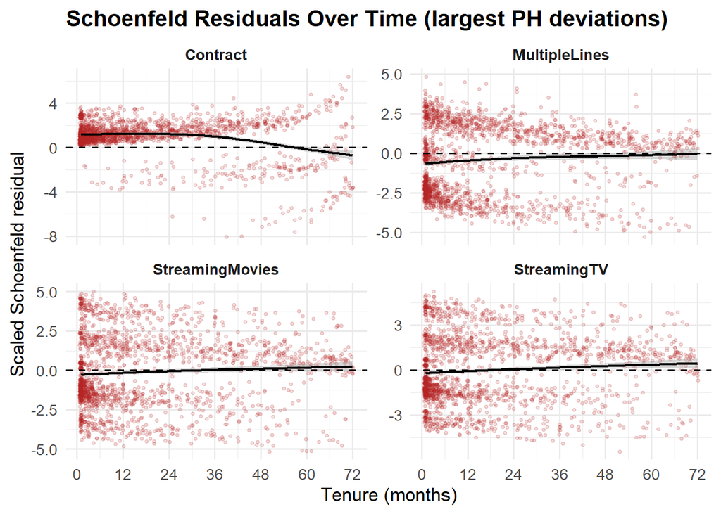

The `cox.zph` global test is significant (p < 0.001), and most covariates show significant chi-squared values. With n = 7,032 this is expected, so the plots matter more than the p-values. The Schoenfeld residual plots for the four largest deviations (`StreamingTV`, `Contract`, `StreamingMovies`, `MultipleLines`) show flat or near-flat trends for the two streaming variables and only a mild drift for `MultipleLines`, whose protective effect weakens slightly with tenure. `Contract` is the one clear violation: its residual trend is flat through roughly month 30, then declines and crosses zero around month 55-60, indicating that the protective effect of longer contracts weakens at long tenures.

### Stratified Cox Model

```r
cox_strat <- coxph(
  Surv(tenure, Churn) ~ . - Contract + strata(Contract),
  data = df_model
)
broom::tidy(cox_strat, exponentiate = TRUE, conf.int = TRUE) %>%
  transmute(
    Term      = term,
    HR        = round(estimate, 2),
    `95% CI`  = sprintf("%.2f – %.2f", conf.low, conf.high),
    `p-value` = ifelse(p.value < 0.001, "<0.001", sprintf("%.3f", p.value))
  ) %>%
  knitr::kable(align = "lrrr")
```

| Term | HR | 95% CI | p-value |
| --- | --- | --- | --- |
| genderMale | 0.93 | 0.85 – 1.02 | 0.114 |
| SeniorCitizenYes | 0.94 | 0.84 – 1.05 | 0.288 |
| PartnerYes | 0.61 | 0.55 – 0.68 | <0.001 |
| DependentsYes | 0.94 | 0.82 – 1.07 | 0.342 |
| PhoneServiceYes | 1.08 | 0.89 – 1.32 | 0.419 |
| MultipleLinesYes | 0.64 | 0.57 – 0.71 | <0.001 |
| InternetServiceFiber optic | 1.46 | 1.27 – 1.69 | <0.001 |
| InternetServiceNo | 0.35 | 0.28 – 0.45 | <0.001 |
| OnlineSecurityYes | 0.52 | 0.46 – 0.60 | <0.001 |
| OnlineBackupYes | 0.53 | 0.48 – 0.59 | <0.001 |
| DeviceProtectionYes | 0.74 | 0.66 – 0.82 | <0.001 |
| TechSupportYes | 0.66 | 0.58 – 0.75 | <0.001 |
| StreamingTVYes | 0.96 | 0.86 – 1.07 | 0.464 |
| StreamingMoviesYes | 0.89 | 0.80 – 0.99 | 0.038 |
| PaperlessBillingYes | 1.20 | 1.07 – 1.34 | 0.001 |
| PaymentMethodCredit card (automatic) | 0.92 | 0.77 – 1.10 | 0.361 |
| PaymentMethodElectronic check | 1.78 | 1.55 – 2.05 | <0.001 |
| PaymentMethodMailed check | 1.79 | 1.51 – 2.13 | <0.001 |

```r
ph_tbl(cox.zph(cox_strat))
```

| Term | Chi-sq | df | p-value |
| --- | --- | --- | --- |
| gender | 0.3 | 1 | 0.566 |
| SeniorCitizen | 4.5 | 1 | 0.034 |
| Partner | 14.3 | 1 | <0.001 |
| Dependents | 0.0 | 1 | 0.987 |
| PhoneService | 6.7 | 1 | 0.009 |
| MultipleLines | 64.9 | 1 | <0.001 |
| InternetService | 76.3 | 2 | <0.001 |
| OnlineSecurity | 15.2 | 1 | <0.001 |
| OnlineBackup | 29.0 | 1 | <0.001 |
| DeviceProtection | 35.4 | 1 | <0.001 |
| TechSupport | 25.2 | 1 | <0.001 |
| StreamingTV | 81.1 | 1 | <0.001 |
| StreamingMovies | 75.9 | 1 | <0.001 |
| PaperlessBilling | 9.1 | 1 | 0.003 |
| PaymentMethod | 45.1 | 3 | <0.001 |
| GLOBAL | 217.0 | 18 | <0.001 |

```r
cc_s <- summary(cox_strat)$concordance
cat(sprintf("Stratified Cox concordance = %.3f (se = %.3f)", cc_s["C"], cc_s["se(C)"]))
```

```
Stratified Cox concordance = 0.720 (se = 0.007)
```

Because `Contract` is also the strongest predictor, the model was refit with `Contract` as a stratification variable, which gives each contract type its own baseline hazard. Hazard ratios for all other covariates were nearly unchanged (e.g. fiber optic 1.46 vs 1.47, electronic check 1.78 vs 1.80), so the conclusions of the main model are robust to this violation. The stratified model’s concordance (0.72) is not comparable to the unstratified model’s, because with strata it only counts pairs within the same contract type.

## Random Survival Forest (Flexible Alternative)

```r
rsf_fit <- rfsrc(
  Surv(tenure, Churn) ~ .,
  data = df_model,
  ntree = 500,
  importance = TRUE,
  seed = -42
)
```

| Setting | Value |
| --- | --- |
| Customers | 7,032 |
| Churn events | 1,869 |
| Trees | 500 |
| Predictors | 16 |
| Variables tried per split | 4 |
| Minimum terminal node size | 15 |
| OOB error (1 - C-index) | 0.1581 |

The RSF achieves an out-of-bag concordance of 0.8419, compared to 0.8664 for the Cox model above. Cox’s figure is computed on the same sample it was fitted on, while the RSF figure is out-of-bag, so the two are not strictly comparable and the gap of about 0.0245 should be read as suggestive. Still, the flexible model shows no clear advantage here, which may mean the relationships driving churn (contract length, payment method, add-on services) are close to linear and additive.

### Variable Importance

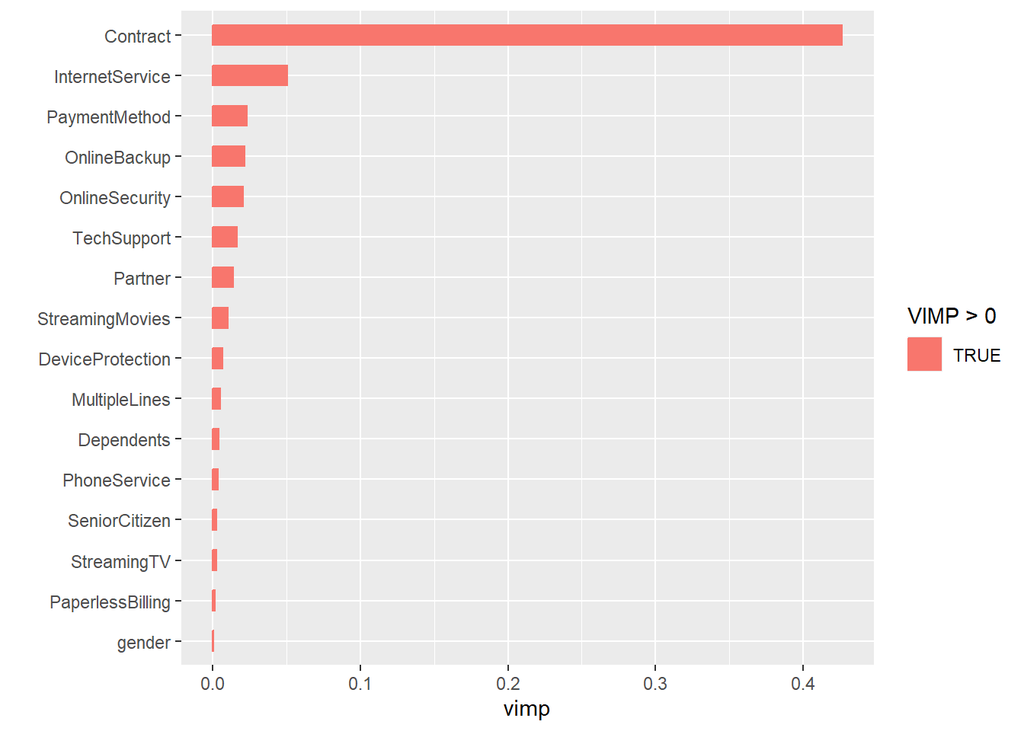

Permutation importance ranks `Contract` far above everything else (about 0.42, roughly eight times the next variable). `InternetService` (about 0.05), `PaymentMethod`, `OnlineSecurity`, `OnlineBackup`, `TechSupport` and `Partner` follow; `gender`, `PaperlessBilling` and `SeniorCitizen` contribute almost nothing. This ordering agrees closely with the Cox hazard ratios, so both models identify the same drivers of churn.

## Model Comparison

| Model | C-index |
| --- | --- |
| Cox PH | 0.8664 |
| RSF | 0.8419 |

Cox PH reaches a concordance of 0.8664, fitted and evaluated on the full sample; RSF reaches 0.8419 out-of-bag. The two figures are not directly comparable: the Cox value is in-sample, while the out-of-bag value is an internal validation estimate. The comparison therefore likely overstates Cox’s advantage, and the gap of about 0.0245 should be read as suggestive, not as a measured difference in predictive performance.

## Business Takeaway

The highest-risk profile from the Cox model is a month-to-month customer on fiber optic internet, paying by electronic or mailed check, without online security or tech support add-ons. Relative to a customer with a two-year contract, automatic payment, and both add-ons, this profile carries a churn hazard many times higher once the individual hazard ratios are compounded.

Two concrete actions follow directly from the model:

1. **Target contract conversion first.** Since contract length produces by far the largest hazard reduction, incentivizing month-to-month customers to move to even a one-year contract (not necessarily two-year) captures most of the available retention benefit. Contract choice is self-selected, so this is an association, not a guaranteed effect of converting customers.
2. **Bundle add-on services into retention offers.** Online security and tech support are associated with about 48% and 34% lower hazard respectively (HR 0.52 and 0.66), independent of contract type – offering these as a retention incentive (rather than a discount alone) targets a pattern the data supports, not just a price lever.

Payment method is also actionable: nudging electronic or mailed-check customers toward automatic payment could plausibly reduce churn, though this should be treated as a correlational signal, not a proven causal lever, without a controlled test.

## Conclusion

This analysis modeled telecom customer churn as a time-to-event process rather than a binary outcome, using Kaplan-Meier curves, Cox Proportional Hazards, and Random Survival Forest. Contract length is by far the strongest retention signal, followed by internet service type, payment method and add-on services such as online security, online backup and tech support. After excluding `TotalCharges` (it encodes the follow-up time) and `MonthlyCharges` (almost fully determined by the service bundle), the Cox model reached a concordance of 0.8664 on the full sample, against 0.8419 out-of-bag for the Random Survival Forest. Because the two figures are computed differently, the gap is suggestive rather than conclusive, but the flexible model showed no clear advantage, so the simpler and more interpretable Cox model is the better choice here. The most actionable lever is contract conversion. The data is a snapshot of a fictional telco, so absolute churn figures should not be read as real-world rates.